# Finding Fast Growing Firms

Data Analysis 3 - Assignment 3 - Prediction and Classification

Peter Kaiser & Xibei Chen

16 February 2022

```r
#### Set up
# Clear environment
rm(list=ls())

# Import libraries
library(glmnet)
library(margins)
library(skimr)
library(cowplot)
library(gmodels)
library(modelsummary)
library(tidyverse)
library(viridis)
library(rattle)
library(caret)
library(pROC)
library(fixest)
library(ranger)
library(rpart)
library(rpart.plot)
library(devtools)
library(ggpubr)
library(kableExtra)


# Import helper functions (credits to Agoston)
devtools::source_url('https://raw.githubusercontent.com/xibei-chen/DA3/main/assignment_3/code/helper_functions.R')
```

# Executive Summary

The purpose of this project is to build a model predicting the probability of a firm being fast growing to support investment decisions. The criteria for being fast growing is measured by us as the average sales growth rate above 15% for the next two years. The probability prediction paves the way for further classification to differentiate firms from fast growing to not fast growing, by applying the optimal threshold which is calculated by minimizing the average expected loss. Our final model of choice is random forest for probability, as it gives the lowest cross-validated RMSE and the highest cross-validated AUC, despite the drawback that random forest is a black box model and it would be hard for us to explain investment choices to other investors. Then for classification, we first define our loss function that for a bad investment we lose 1000 Euros, whereas to miss a good investment opportunity costs us 3000 Euros. Random forest again performs the best among all the models, as it gives the lowest averaged expected loss. However, according to the confusion matrix, we see that the classification model does not really perform well, as the accuracy is only 51% on holdout sample. And there is not much difference for different industry subsamples. As the performance is no better than random guessing, we would suggest to conduct further research to get a better model by optimizing our feature engineering process and exploring other classification models as well such as GBM classification.

# Introduction

The data and code used for this project can be accessed on this [GitHub Repo](https://github.com/xibei-chen/DA3/tree/main/assignment_3). The approach of methods for our analysis in this project is inspired by Bisnode case study conducted by Békés and Kézdi in book [“Data Analysis for Business, Economics and Policy”](https://gabors-data-analysis.com/) (Chapter 17).

The structure of our report is as follows:

1. Data management: label and feature engineering, sample design
2. Define variable sets and model setup
3. Probability prediction
4. Classification
5. Extra task - random forest classification on different industry subsamples
6. Further research

# Data Management

The raw data for this project can be found on Békés and Kézdi’s [data repository](https://osf.io/b2ft9/). The original dataset was collected, maintained and cleaned by [Bisnode](https://www.bisnode.com/), a major European business information company. The raw data represents all of the registered companies between 2005 and 2016 in a medium-sized European country. The variable descriptions for Bisnode dataset are accessible on this [Excel sheet](https://github.com/xibei-chen/DA3/blob/main/assignment_3/data/bisnode_variable_names.xls).

### Label Engineering

```r
# Label engineering
####################
# Add all missing year and comp_id combinations
# Originally missing combinations will have NAs in all other columns
data <- data %>% complete(year, comp_id)

# Generate status_alive; if sales larger than zero and not-NA, then firm is alive
data  <- data %>% mutate(status_alive = sales > 0 & !is.na(sales))
data$status_alive <- as.numeric(data$status_alive)

# Generate default in two years if there are sales in this year but no sales two years later
data <- data %>%
        group_by(comp_id) %>%
        mutate(default = ((status_alive == 1) & (lead(status_alive, 2) == 0)) %>%
                       as.numeric(.)) %>%
        ungroup()

# Check sales
#summary(dataf$sales)

# Transform sales variables
data <- data %>%
        mutate(sales = ifelse(sales < 0, 1, sales),
               ln_sales = ifelse(sales > 0, log(sales), 0),
               sales_mil=sales/1000000,
               sales_mil_log = ifelse(sales > 0, log(sales_mil), 0))

data <- data %>%
        group_by(comp_id) %>%
        mutate(d1_sales_mil = sales_mil - lag(sales_mil,1),
               d1_sales_mil_log = sales_mil_log - lag(sales_mil_log, 1)) %>%
        ungroup()

# Replace w 0 for new firms + add dummy to capture it
data <- data %>%
        mutate(age = (year - founded_year) %>%
                       ifelse(. < 0, 0, .),
               new = as.numeric(age <= 1) %>% #  (age could be 0,1 )
                       ifelse(balsheet_notfullyear == 1, 1, .),
               d1_sales_mil_log = ifelse(new == 1, 0, d1_sales_mil_log),
               new = ifelse(is.na(d1_sales_mil_log), 1, new),
               d1_sales_mil_log = ifelse(is.na(d1_sales_mil_log), 0, d1_sales_mil_log))

# Add new variables for measuring growth rate for the next year and in two years
data <- data %>%
        group_by(comp_id) %>%
        mutate(u12_sales_mil = lead(sales_mil,2) - lead(sales_mil,1),
               u1_sales_gr = (lead(sales_mil,1) - sales_mil)/sales_mil*100,
               u12_sales_gr = u12_sales_mil/lead(sales_mil,1)*100) %>%
        ungroup()

# Define fast growth
######################
# 1. flag_high_d1_sales_mil_log: 1.5
#nrow(data %>% filter(d1_sales_mil_log > 1.5)) #10053/556944 around 2%

# 2. Formula: sales growth rate = d1_sales_mil/lag(sales_mil,1)*100
#nrow(data %>% filter(u1_sales_gr>=15)) #77814/556944 around 14%
#nrow(data %>% filter(u1_sales_gr>=15 & u12_sales_gr>=15) ) #23156/556944 around 4%
#nrow(data %>% filter((u1_sales_gr + u12_sales_gr)>=30 )) #64331/556944 around 12%

# Decide to use the last one as less class imbalance, take two years into account and easier to interpret than log
data <- data %>% mutate(fast_growing = ifelse((data$u1_sales_gr + data$u12_sales_gr)>=30 , 1, 0))
```

The target variable needs to be engineered by a growth metric.

One potential approach would be to use log level of sales difference between this year and last year in unit of a million euros, as used as a flag variable in feature engineering for sales change in Békés and Kézdi’s prep code, flag high if log level of sales difference between this year and last year in unit of a million euros is above 1.5. However, this gives a result of only 2% of all the observations are defined as fast growing. We know that most machine learning algorithms work best when the number of samples in each class are close to be equal, as most algorithms are designed to maximize accuracy and reduce errors. If the data set in such imbalance like in this case, we would get a pretty high accuracy just by predicting the majority class, but we would fail to capture the minority class, which is most often the point of creating the model in the first place.

Hence, we tend to choose another more lenient criteria for defining fast growing firms. By doing some research online, we get some domain knowledge that in general an ideal sales growth rate will be around 15 and 25% annually. We also know that healthy growth rate should be sustainable for the firm, as rates too high may overwhelm new businesses, which may be unable to keep up with such rapid development. We tried a few alternatives, with setting criteria as annual sales growth rate above 15% for next year, for both next two years, and as averaged annual sales growth rate above 15% for the next two years.

To take care of the class imbalance issue we discussed previously, and to take longer term namely next two years and easy interpretability into consideration as well, as our final choice, firms with average annual sales growth rate above 15% for the next two years are categorized as fast growing, otherwise as not fast growing.

### Sample Design

```r
# Sample design
# Filter data for status alive small and medium size firms in 2012
# Exclude large firms with above 10m euros revenue and firms with lower than 1000 euros revenue
data <- data %>% filter(year == 2012,
                    status_alive == 1,
                    sales >= 1000,
                    sales_mil <= 10)

# Exclude firms that had invalid sales growth rate due to lack of information due to certain years
data <- data %>%
        filter(!u1_sales_gr ==Inf & !u12_sales_gr == Inf)

# Drop observations with no target variable fast growth rate
data<- data %>% filter(!is.na(fast_growing))
```

We only selected year 2012 to conduct our prediction and classification. Plus, we tried to mitigate the effects of extreme values in our prediction, so we decided to only focus on the small and medium enterprise sector, captured by firms’ sales. We only keep firms below 10 million euros of annual sales and drop firms with sales below 1000 euros. Furthermore, we also excluded firms that had invalid sales growth rate due to lack of information for certain years. Firms without values for other key variables such as age, region and industry were also dropped.

As a result of our sample design, we have 17984 firms in our full cleaned workfile. These are firms that reported sales between 1 thousand and 10 million euros in 2012. After these sample design steps, we find that 6987, or around 39% of firms will be fast growing in the next two years.

### Feature Engineering

We added some features to capture potential non-linearity such as squared age and squared log sales. As shown in below graphs, we can see that probabilities of fast growing is expected to be lower with firms getting old at the beginning, however after 15 years old, probabilities of fast growing is expected to have a positive correlation with firm age. And when company has not good sales performance, that might lead them make change to invest more in generate more sales, which might overwhelm their business to result in a less likelihood of fast growing. However, if company has already had more than 1 million euros revenue, that might mean they are already in a good track, so their probabilities of fast growing would not change much with the increase of sales.

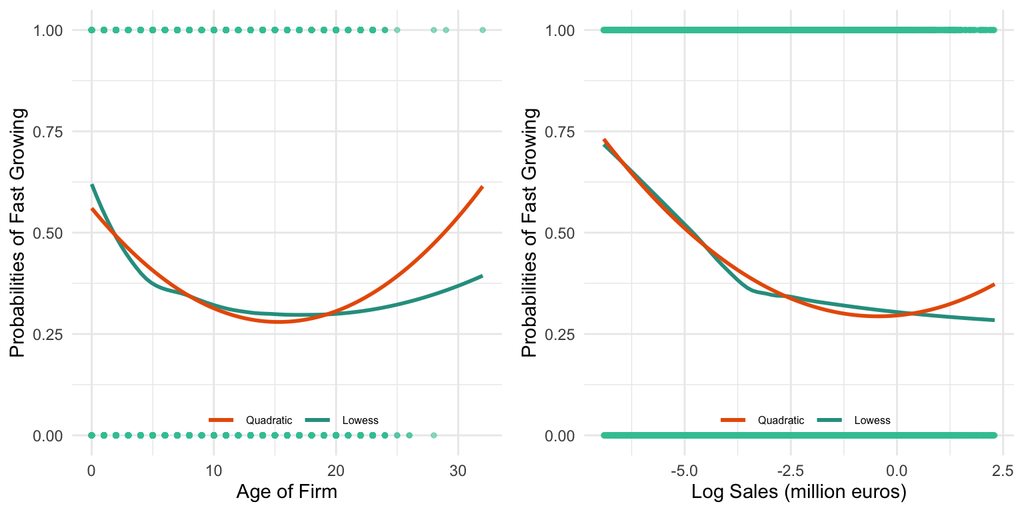

Some flag variables were also created to indicate foreign management, if there is asset problem, etc. We have also winsorized some variables, such as CEO age and log level of sales difference as shown below in the graphs. We winsorized CEO age to be between 25 and 75 years old and log level of sales difference to be between -1.5 and +1.5. After feature engineering, some observations are dropped due to lack of information of key information such as firm age, share of foreign CEOs, industry category, etc.

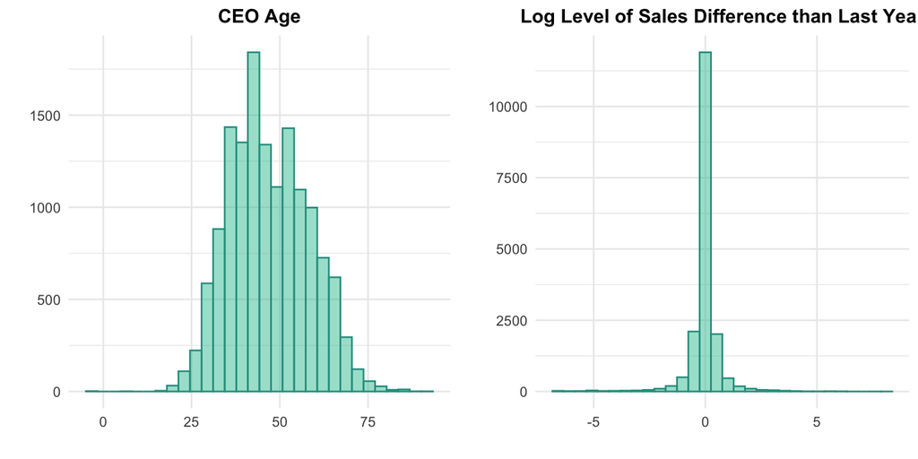

```r
# Feature engineering
######################
# Add firm characteristics
data <- data %>%
        mutate(age2 = age^2,
               foreign_management = as.numeric(foreign >= 0.5))

# Look at more financial variables, create ratios
# Assets can't be negative. Change them to 0 and add a flag.
data <-data  %>%
        mutate(flag_asset_problem=ifelse(intang_assets<0 | curr_assets<0 | fixed_assets<0,1,0  ))

#table(data$flag_asset_problem)

data <- data %>%
        mutate(intang_assets = ifelse(intang_assets < 0, 0, intang_assets),
               curr_assets = ifelse(curr_assets < 0, 0, curr_assets),
               fixed_assets = ifelse(fixed_assets < 0, 0, fixed_assets))

# Generate total assets
data <- data %>%
        mutate(total_assets_bs = intang_assets + curr_assets + fixed_assets)

#summary(data$total_assets_bs)


pl_names <- c("extra_exp","extra_inc",  "extra_profit_loss", "inc_bef_tax" ,"inventories",
              "material_exp", "profit_loss_year", "personnel_exp")
bs_names <- c("intang_assets", "curr_liab", "fixed_assets", "liq_assets", "curr_assets",
              "share_eq", "subscribed_cap", "tang_assets" )

# Divide all pl_names elements by sales and create new column for it
data<- data %>%
        mutate_at(vars(pl_names), funs("pl"=./sales))

# Divide all bs_names elements by total_assets_bs and create new column for it
data <- data %>%
        mutate_at(vars(bs_names), funs("bs"=ifelse(total_assets_bs == 0, 0, ./total_assets_bs)))

# Variables that represent accounting items that cannot be negative (e.g. materials)
zero <-  c("extra_exp_pl", "extra_inc_pl", "inventories_pl", "material_exp_pl", "personnel_exp_pl",
           "curr_liab_bs", "fixed_assets_bs", "liq_assets_bs", "curr_assets_bs", "subscribed_cap_bs",
           "intang_assets_bs")


data <- data %>%
        mutate_at(vars(zero), funs("flag_high"= as.numeric(.> 1))) %>%
        mutate_at(vars(zero), funs(ifelse(.> 1, 1, .))) %>%
        mutate_at(vars(zero), funs("flag_error"= as.numeric(.< 0))) %>%
        mutate_at(vars(zero), funs(ifelse(.< 0, 0, .)))

# For vars that could be any, but are mostly between -1 and 1
any <-  c("extra_profit_loss_pl", "inc_bef_tax_pl", "profit_loss_year_pl", "share_eq_bs")

data <- data %>%
        mutate_at(vars(any), funs("flag_low"= as.numeric(.< -1))) %>%
        mutate_at(vars(any), funs(ifelse(.< -1, -1, .))) %>%
        mutate_at(vars(any), funs("flag_high"= as.numeric(.> 1))) %>%
        mutate_at(vars(any), funs(ifelse(.> 1, 1, .))) %>%
        mutate_at(vars(any), funs("flag_zero"= as.numeric(.== 0))) %>%
        mutate_at(vars(any), funs("quad"= .^2))


# Additional: include some imputation
# CEO age
data<- data %>%
        mutate(ceo_age = year-birth_year,
               flag_low_ceo_age = as.numeric(ceo_age < 25 & !is.na(ceo_age)),
               flag_high_ceo_age = as.numeric(ceo_age > 75 & !is.na(ceo_age)),
               flag_miss_ceo_age = as.numeric(is.na(ceo_age)))

# Kernal density curve for CEO age
p3 <- ggplot( data = data, aes( x = ceo_age ) ) +
  geom_histogram(color='#2a9d8f',fill='#3cc5a3', alpha=0.5) +
  labs( x='', y="",
        title= 'CEO Age') +
  theme_minimal() +
  theme( panel.grid.minor.x = element_blank(),
         plot.title = element_text( size = 12, face = "bold", hjust = 0.5 ) )


# Get rid of the extreme, winsorize and impute
data <- data %>%
        mutate(ceo_age = ifelse(ceo_age < 25, 25, ceo_age) %>%
                       ifelse(. > 75, 75, .) %>%
                       ifelse(is.na(.), mean(., na.rm = TRUE), .),
               ceo_young = as.numeric(ceo_age < 40))

# Number of employees, flag missing values, impute with mean
data <- data %>%
        mutate(labor_avg_mod = ifelse(is.na(labor_avg), mean(labor_avg, na.rm = TRUE), labor_avg),
               flag_miss_labor_avg = as.numeric(is.na(labor_avg)))

#summary(data$labor_avg)
#summary(data$labor_avg_mod)
data <- data %>%
        select(-labor_avg)

# Create factors
data <- data %>%
        mutate(urban_m = factor(urban_m, levels = c(1,2,3)),
               ind2 = factor(ind2, levels = sort(unique(data$ind2))),
               ind = factor(ind, levels=c(1,2,3)))

# Sales
data <- data %>%
        mutate(sales_mil_log_sq=sales_mil_log^2)

# Sales change
# Check Log Level of Sales Difference than Last Year
p4 <- ggplot( data = data, aes( x = d1_sales_mil_log ) ) +
  geom_histogram(color='#2a9d8f',fill='#3cc5a3', alpha=0.5) +
  labs( x='', y="",
        title= 'Log Level of Sales Difference than Last Year') +
  theme_minimal() +
  theme( panel.grid.minor.x = element_blank(),
         plot.title = element_text( size = 12, face = "bold", hjust = 0.5 ) )

# Flag and winsorize, add feature
data <- data %>%
        mutate(flag_low_d1_sales_mil_log = ifelse(d1_sales_mil_log < -1.5, 1, 0),
               flag_high_d1_sales_mil_log = ifelse(d1_sales_mil_log > 1.5, 1, 0),
               d1_sales_mil_log_mod = ifelse(d1_sales_mil_log < -1.5, -1.5,
                                             ifelse(d1_sales_mil_log > 1.5, 1.5, d1_sales_mil_log)),
               d1_sales_mil_log_mod_sq = d1_sales_mil_log_mod^2
        )

# Dropping flags with no variation
variances<- data %>%
        select(contains("flag")) %>%
        apply(2, var, na.rm = TRUE) == 0

data<- data %>%
        select(-one_of(names(variances)[variances]))


# Drop observations if key vars are missing
data <- data %>%
        filter(!is.na(liq_assets_bs),!is.na(foreign),!is.na(ind),!is.na(age),
               !is.na(foreign),!is.na(material_exp_pl),!is.na(region_m))

# Drop levels with zero observation for industry
data$ind2 <- droplevels(data$ind2)

# Convert character variables to factors
data <- data%>% mutate_if(is.character, factor)

# Create factors for target
data <- data %>%
        mutate(fast_growing_f = factor(fast_growing, levels = c(0,1)) %>%
                       recode(., `0` = 'not_fast_growing', `1` = "fast_growing"))
```

At this point, we have 15835 firms in our dataset, among which 6010 or around 38% of firms are categorized as fast growing in the next two years, as shown in the graph below.

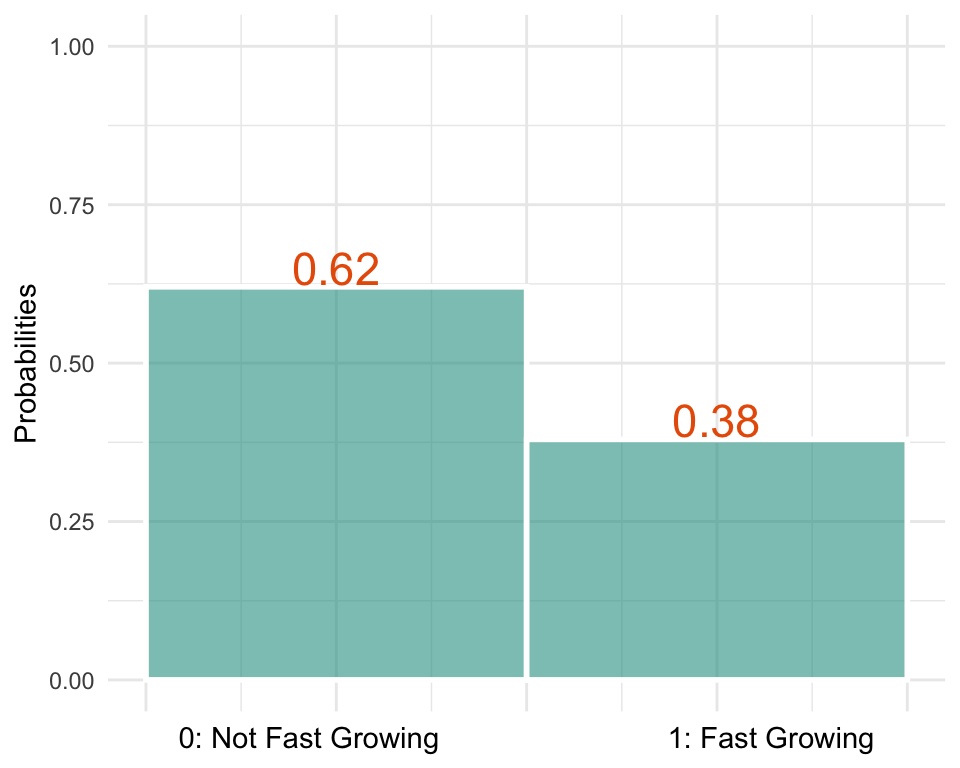

```r
ggplot( data = data , aes( x = fast_growing,label=  ..count.. / sum( count ) ) ) +
        geom_histogram( aes( y = ..count.. / sum( count ) ) , size = 1 , fill = '#2a9d8f',alpha=0.6,color="white",
                        bins = 2)+
        annotate("text", size=6, colour="#e85d04",x=1, y=0.41, label= round(nrow(data %>% filter(fast_growing==1))/nrow(data),2 ))+
        annotate("text", size=6, colour="#e85d04",x=0, y=0.65, label= round(nrow(data %>% filter(fast_growing==0))/nrow(data),2 ))+
        labs(y='Probabilities',x='0: Not Fast Growing                            1: Fast Growing')+
        ylim(0,1) +
        theme_minimal()+
        theme(axis.text.x=element_blank())
```

# Predictor Variables and Model Setup

First, we created following variable groups for later model choices.

- Basic firm variables
- Firm financial quality variables
- Extra financial variables group 1
- Extra financial variables group 2
- Flag variables
- Growth variables
- Human resource variables
- Firm demographic variables
- Interaction between industry and some other variables
- Interaction between log sales and some other variables

```r
# Define variable sets for modelling
# Basic firm variables
basicvars <-  c("curr_assets", "curr_liab", "extra_exp", "extra_inc", "extra_profit_loss", "fixed_assets", "inc_bef_tax", "intang_assets", "inventories", "liq_assets", "material_exp", "personnel_exp", "profit_loss_year", "sales", "share_eq", "subscribed_cap")

# Further financial variables
qualityvars <- c("balsheet_flag", "balsheet_length", "balsheet_notfullyear")
extravars1 <- c("total_assets_bs", "fixed_assets_bs", "liq_assets_bs", "curr_assets_bs",
                "share_eq_bs", "subscribed_cap_bs", "intang_assets_bs", "extra_exp_pl",
                "extra_inc_pl", "extra_profit_loss_pl", "inc_bef_tax_pl", "inventories_pl",
                "material_exp_pl", "profit_loss_year_pl", "personnel_exp_pl")
extravars2 <- c("extra_profit_loss_pl_quad", "inc_bef_tax_pl_quad",
                "profit_loss_year_pl_quad", "share_eq_bs_quad")

# Flag variables
flagvars <- c(grep("*flag_low$", names(data), value = TRUE),
              grep("*flag_high$", names(data), value = TRUE),
              grep("*flag_error$", names(data), value = TRUE),
              grep("*flag_zero$", names(data), value = TRUE))

# Growth variables
growthvars <-  c("d1_sales_mil_log_mod", "d1_sales_mil_log_mod_sq",
                 "flag_low_d1_sales_mil_log", "flag_high_d1_sales_mil_log" )

# Human capital related variables
hrvars <- c("female", "ceo_age", "flag_high_ceo_age", "flag_low_ceo_age",
            "flag_miss_ceo_age", "ceo_count", "labor_avg_mod",
            "flag_miss_labor_avg", "foreign_management")

# Firms demographic related variables
firmvars <- c("age", "age2", "new", "ind2", "region_m", "urban_m")

# interactions for logit, LASSO
interactions_ind2 <- c("ind2*age", "ind2*age2",
                        "ind2*d1_sales_mil_log_mod", "ind2*sales_mil_log",
                        "ind2*ceo_age", "ind2*foreign_management",
                        "ind2*female",   "ind2*urban_m", "ind2*labor_avg_mod")
interactions_sml <- c("sales_mil_log*age", "sales_mil_log*female",
                   "sales_mil_log*profit_loss_year_pl", "sales_mil_log*foreign_management")
```

Then we set up the 5 simple logit models with increasing model complexity for further analysis. And we use the same predictor variables of simple logit model 5 for logit lasso. Lastly we set up a random forest model excluding interactions, modified features and flag variables, as random forest can catch those information automatically.

- M1: log level sales, squared log level sales, modified log level sales difference than last year, ratio of annual profit loss year to sales and industry;
- M2: on the basis of M1, add ratio of fixed assets to total assets, ratio of shareholder equity to total assets, ratio of current liabilities to total assets, and the flag of it being high or error, firm age and foreign management;
- M3: log level sales, squared log level sales, firm demographic variables, extra financial variables group 1 and growth variables;
- M4: on the basis of M3, add extra financial variables group 2, flag variables, human resource variables and firm financial quality variables;
- M5: on the basis of M4, add interactions of industry and log sales with some other variables;
- Lasso: same as M5;
- Random Forest: sales in million units, log level sales difference than last year, basic firm variables, human resource variables, firm demographic variables and firm financial quality variables.

```r
# Model setups
# 1) Simple logit models
M1 <- c("sales_mil_log", "sales_mil_log_sq", "d1_sales_mil_log_mod", "profit_loss_year_pl", "ind2")
M2 <- c("sales_mil_log", "sales_mil_log_sq", "d1_sales_mil_log_mod", "profit_loss_year_pl", "fixed_assets_bs","share_eq_bs","curr_liab_bs ",   "curr_liab_bs_flag_high ", "curr_liab_bs_flag_error",  "age","foreign_management" , "ind2")
M3 <- c("sales_mil_log", "sales_mil_log_sq", firmvars, extravars1, growthvars)
M4 <- c("sales_mil_log", "sales_mil_log_sq", firmvars, extravars1, extravars2, flagvars, growthvars, hrvars, qualityvars)
M5 <- c("sales_mil_log", "sales_mil_log_sq", firmvars, extravars1, extravars2, flagvars, growthvars, hrvars, qualityvars, interactions_ind2, interactions_sml)

# 2) logit+LASSO
lassovars <- c("sales_mil_log", "sales_mil_log_sq", firmvars, extravars1, extravars2, flagvars, growthvars, hrvars, qualityvars, interactions_ind2, interactions_sml)

# 3) CART and RF (no interactions, no modified features, , no flag variables)
rfvars  <-  c("sales_mil", "d1_sales_mil_log", basicvars, hrvars, firmvars, qualityvars)
```

# Probability Prediction

First, we use random sampling to create a training set with 80% of the observations, the left 20% will be used as holdout set for evaluation our model choice. Furthermore, to find the best performing threshold-agnostic model, we use 5-fold cross-validated RMSE as well as the average area under the curve (AUC) for each model.

```r
set.seed(20220214)
# Create train and holdout samples
train_indices <- as.integer(createDataPartition(data$fast_growing, p = 0.8, list = FALSE))
data_train    <- data[train_indices, ]
data_holdout  <- data[-train_indices, ]

# 5 fold cross-validation:
#   check the summary function
train_control <- trainControl(
        method = "cv",
        number = 5,
        classProbs = TRUE,
        summaryFunction = twoClassSummaryExtended,
        savePredictions = TRUE
)
```

### Logit Models

We first estimate 5 simple logit models with predictors we set previously. From M1 to M5, the number of predictors and hence coefficients are increasing and models become more complex. We fit a logit model for each of these predictor sets using 5-fold cross-validation. Then we fit ROC curves for each of the folds for every model to get the average AUC.

```r
####
#Cross-Validate Logit Models
logit_model_vars <- list("M1" = M1, "M2" = M2, "M3" = M3, "M4" = M4, "M5" = M5)

CV_RMSE_folds <- list()
logit_models <- list()

for (model_name in names(logit_model_vars)) {

        # setting the variables for each model
        features <- logit_model_vars[[model_name]]

        # Estimate logit model with 5-fold CV
        set.seed(20220214)
        glm_model <- train(
                formula(paste0("fast_growing_f ~", paste0(features, collapse = " + "))),
                method    = "glm",
                data      = data_train,
                family    = binomial,
                trControl = train_control
        )

        # Save the results to list
        logit_models[[model_name]] <- glm_model
        # Save RMSE on test for each fold
        CV_RMSE_folds[[model_name]] <- glm_model$resample[,c("Resample", "RMSE")]

}
```

### Logit Lasso

Next we estimate logit Lasso. We fit the model with the same predictor sets for simple logit model 5 which is of the highest complexity and covers all the modified features, flags and interactions. We arbitrarily set alpha as 1, and set the lambda parameter to be between 0.1 and 0.0001 letting the machine decide the optimal lambda parameter. Then we do the same to Lasso model as we did for previous simple logit models, we use 5 fold for cross-validation. And we fit ROC curves for each of the folds for every model to get the average AUC.

### Random Forest

Lastly, we estimated random forest using the predictor sets we defined previously which do not contain modified features, flags and interactions. In terms of tuning parameters, we set the number of randomly chosen variables at each split to be either 5, 6 or 7, as they are around the square root of the total number of predictors used to estimate the model. The number of observations in the terminal nodes of each tree is set to be either 10 or 15. It turns out the optimal random forest model has 15 observations in the terminal nodes and 5 variables randomly chosen at each split. We still use 5-fold cross-validation for random forest. And we use this model to fit ROC curves for its folds to get the average AUC value.

```r
# Calculate the ROC Curve and calculate AUC for each folds
# Calculate AUC for each fold
CV_AUC_folds <- list()
for (model_name in names(logit_models)) {

        auc <- list()
        model <- logit_models[[model_name]]
        for (fold in c("Fold1", "Fold2", "Fold3", "Fold4", "Fold5")) {
                # get the prediction from each fold
                cv_fold <-
                        model$pred %>%
                        filter(Resample == fold)
                # calculate the roc curve
                roc_obj <- roc(cv_fold$obs, cv_fold$fast_growing, quiet = TRUE)
                # save the AUC value
                auc[[fold]] <- as.numeric(roc_obj$auc)
        }

        CV_AUC_folds[[model_name]] <- data.frame("Resample" = names(auc),
                                                 "AUC" = unlist(auc))
}


# For each model: average RMSE and average AUC for each models

CV_RMSE <- list()
CV_AUC <- list()

for (model_name in names(logit_models)) {
        CV_RMSE[[model_name]] <- mean(CV_RMSE_folds[[model_name]]$RMSE)
        CV_AUC[[model_name]] <- mean(CV_AUC_folds[[model_name]]$AUC)
}


# We have 7 models, (5 simple logit, logit lasso, and random forest). For each we have a 5-CV RMSE and AUC.
# We pick our preferred model based on that.

nvars <- lapply(logit_models, FUN = function(x) length(x$coefnames))
# quick adjustment for LASSO
nvars[["LASSO"]] <- sum(lasso_coeffs != 0)

logit_summary1 <- data.frame("Number of predictors" = unlist(nvars),
                             "CV RMSE" = unlist(CV_RMSE),
                             "CV AUC" = unlist(CV_AUC))

# Summary for average RMSE and AUC for each model on the test sample
#logit_summary1
```

### Model Comparison (threshold-agnostic)

```r
knitr::kable( logit_summary1, caption = "Model Prediction Performance Summary (threshold-agnostic) ", col.names = c("Number of predictors", "CV RMSE", "CV AUC"), digits=4) %>% kable_styling( position = "center", latex_options = 'hold_position' )
```

Model Prediction Performance Summary (threshold-agnostic)

|  | Number of predictors | CV RMSE | CV AUC |
| --- | --- | --- | --- |
| M1 | 11 | 0.4763 | 0.6045 |
| M2 | 18 | 0.4697 | 0.6420 |
| M3 | 35 | 0.4663 | 0.6575 |
| M4 | 78 | 0.4654 | 0.6600 |
| M5 | 152 | 0.4655 | 0.6621 |
| LASSO | 56 | 0.4643 | 0.6474 |
| Random Forest | 44 | 0.4627 | 0.6674 |

From the above summary table, we can get following conclusions.

1. As M4 has slightly better CV RMSE than M5, we can say that more complex models do not always generate better predictions, after certain point, including more predictors might result in overfitting training data.
2. Our Logit Lasso model gets better CV RMSE than all the above simple Logit models, however it does not get the best CV AUC. This is due to the fact that here the setting for Lasso is to optimize RMSE not AUC.
3. The model with best prediction performance is Random Forest, as it has the lowest CV RMSE and the highest CV AUC.

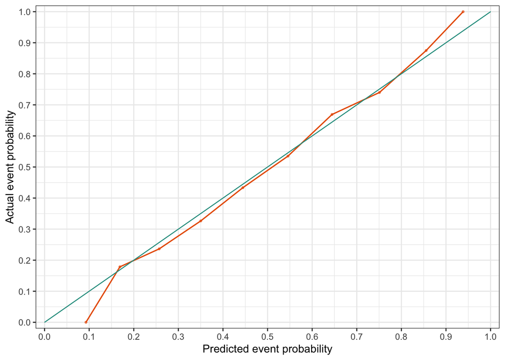

```r
# Plot calibration curve
create_calibration_plot(data_holdout,
                        prob_var = "best_model_no_loss_pred",
                        actual_var = "fast_growing",
                        n_bins = 10)
```

# Classification

For turning predicted probabilities into classifications, we need a classification threshold. To determine the threshold, we need to define our loss function. Then we can look for the optimal threshold in each model. Eventually we can decide which model is the best model based on lowest average expected loss.

### Define Loss Function

To define our loss function , we need to assign a cost value to False Positive (FP) and False Negative (FN) classifications. Before that, we need to clarify that in our project False Positive means bad investment, that we classify a firm as fast growing and we invest in it, while in fact it is not a fast growing firm, hence we would lose our investment money or not generate as much profit as we expected. False Negative means the opposite, that we classify a firm as not fast growing and do not invest in it, while in fact it is fast growing, hence we would lose the investment opportunity. We decided that FN (losing an investment opportunity for a fast growing firm) would cost us 3000 Euros, more than FP (investing in a firm that is not fast growing) cost us 1000 Euros. Therefore, we set the ratio of the costs of FP to FN decisions as 1/3.

```r
# Introduce loss function
# relative cost of of a false negative classification (as compared with a false positive classification)
# FP: bad investment FN: potential business opportunity
FP=1
FN=3
cost = FN/FP
# the prevalence, or the proportion of cases in the population (n.cases/(n.controls+n.cases))
prevelance = sum(data_train$fast_growing)/length(data_train$fast_growing)

# Draw ROC Curve and find optimal threshold WITH loss function
best_tresholds <- list()
expected_loss <- list()
logit_cv_rocs <- list()
logit_cv_threshold <- list()
logit_cv_expected_loss <- list()

# Iterate through models and folds
for (model_name in names(logit_models)) {

        model <- logit_models[[model_name]]
        colname <- paste0(model_name,"_prediction")

        best_tresholds_cv <- list()
        expected_loss_cv <- list()

        for (fold in c("Fold1", "Fold2", "Fold3", "Fold4", "Fold5")) {
                cv_fold <-
                        model$pred %>%
                        filter(Resample == fold)

                roc_obj <- roc(cv_fold$obs, cv_fold$fast_growing, quiet = TRUE)
                # Add the weights (costs) here!
                best_treshold <- coords(roc_obj, "best", ret="all", transpose = FALSE,
                                        best.method="youden", best.weights=c(cost, prevelance))
                # save best threshold for each fold and save the expected loss value
                best_tresholds_cv[[fold]] <- best_treshold$threshold
                expected_loss_cv[[fold]] <- (best_treshold$fp*FP + best_treshold$fn*FN)/length(cv_fold$fast_growing)
        }

        # average
        best_tresholds[[model_name]] <- mean(unlist(best_tresholds_cv))
        expected_loss[[model_name]]  <- mean(unlist(expected_loss_cv))

        # for fold #5
        logit_cv_rocs[[model_name]] <- roc_obj
        logit_cv_threshold[[model_name]] <- best_treshold
        logit_cv_expected_loss[[model_name]] <- expected_loss_cv[[fold]]

}

logit_summary2 <- data.frame("Avg of optimal thresholds" = unlist(best_tresholds),
                             "Threshold for Fold5" = sapply(logit_cv_threshold, function(x) {x$threshold}),
                             "Avg expected loss" = unlist(expected_loss),
                             "Expected loss for Fold5" = unlist(logit_cv_expected_loss))

#logit_summary2
```

### Model Comparison (optimal thresholds)

For each model, we fit a ROC curve for each fold, saved best threshold for each fold and the expected loss value, then we calculated the average optimal thresholds and the average expected loss. We can compare models based on the average expected loss.

```r
knitr::kable( logit_summary2, caption = "Model Prediction Performance Summary (optimal thresholds) ", col.names = c("Avg of optimal thresholds","Threshold for fold #5", "Avg expected loss","Expected loss for fold #5"), digits = 4 ) %>% kable_styling( position = "center", latex_options = 'hold_position' )
```

Model Prediction Performance Summary (optimal thresholds)

|  | Avg of optimal thresholds | Threshold for fold #5 | Avg expected loss | Expected loss for fold #5 |
| --- | --- | --- | --- | --- |
| M1 | 0.2642 | 0.2433 | 0.6125 | 0.6160 |
| M2 | 0.2299 | 0.2300 | 0.6030 | 0.6097 |
| M3 | 0.2397 | 0.2273 | 0.5916 | 0.5931 |
| M4 | 0.2423 | 0.2064 | 0.5910 | 0.5896 |
| M5 | 0.2371 | 0.2203 | 0.5910 | 0.5935 |
| LASSO | 0.2392 | 0.2321 | 0.6006 | 0.5989 |
| Random Forest | 0.2780 | 0.2237 | 0.5826 | 0.5848 |

From the above summary table, we can conclude that the random forest is still the best model at classification, as it has the lowest average expected loss. The second best is M4 or M5. The difference between their averaged expected loss is around 8 euros. However, if we review 1000 firms, this would result into 8000 euros difference.

### Visualization of Optimal Threshold for Lowest Expected Loss

As Random Forest model performs the best, we tried to visualize the expected loss for different thresholds using the Fold #5 below on the left. We can see in the plot that the threshold which minimizes the loss function is 0.22 which is around 0.05 lower than the average optimal threshold, while the minimum of loss is 0.58 which is the same as the average. We can also see the ROC curve for the same fold on the right side and the best threshold point is marked where expected loss is minimized. In addition, the TP and TN rates at that threshold point are shown in the plot.

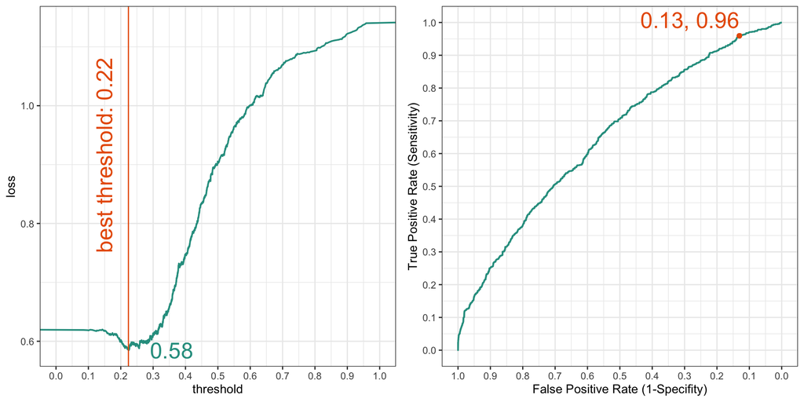

We use the random forest model for classification on the holdout sample by applying the threshold of 0.278 and get an average expected loss of 0.57, which is similar to that in the training sample. This means if we use this model for classification, we would expect to lose 570 euros on average.

```r
# Take model to holdout and estimate RMSE, AUC and expected loss
# Get model with optimal threshold
best_model_with_loss <- logit_models[["Random Forest"]]
best_model_optimal_treshold <- best_tresholds[["Random Forest"]]

# Predict the probabilities on holdout
rf_predicted_probabilities_holdout      <- predict(best_model_with_loss, newdata = data_holdout, type = "prob")
data_holdout[,"best_model_with_loss_pred"] <- rf_predicted_probabilities_holdout[,"fast_growing"]

# ROC curve on holdout
roc_obj_holdout <- roc(data_holdout$fast_growing, data_holdout[, "best_model_with_loss_pred", drop=TRUE],quiet = TRUE)

# Get expected loss on holdout:
holdout_treshold <- coords(roc_obj_holdout, x = best_model_optimal_treshold, input= "threshold",
                           ret="all", transpose = FALSE)

# Calculate the expected loss on holdout sample
expected_loss_holdout <- (holdout_treshold$fp*FP + holdout_treshold$fn*FN)/length(data_holdout$fast_growing)
#expected_loss_holdout #0.5740448
```

# Confusion Matrix for Best Model

As the last step of the classification process we create a confusion matrix from the classification on the holdout set using the random forest model.

```r
# Confusion table on holdout with optimal threshold
holdout_prediction <-
        ifelse(data_holdout$best_model_with_loss_pred < best_model_optimal_treshold, "not_fast_growing", "fast_growing") %>%
        factor(levels = c("not_fast_growing", "fast_growing"))
cm_object <- confusionMatrix(holdout_prediction,data_holdout$fast_growing_f)
cm <- cm_object$table
# in pctg
cm_round <- round( cm / sum(cm) * 100  )
knitr::kable(cm_round, caption = "Confusion matrix for best model random forest on holdout sample (%) [rows: predicted, columns: actual]" ) %>% kable_styling( position = "center", latex_options = 'hold_position' )
```

Confusion matrix for best model random forest on holdout sample (%) [rows: predicted, columns: actual]

|  | not_fast_growing | fast_growing |
| --- | --- | --- |
| not_fast_growing | 18 | 4 |
| fast_growing | 45 | 33 |

According to the matrix, the rate of FP is 45%, while the rate of FN is 4%. This is due to the cost functions we defined. So the ratio of the less costly false decision is higher than the more costly false decision. To sum up, the accuracy of this classification is only around 51%, which is not an ideal classification, as it is just a bit better than random guessing.

# Random Forest Classification on Different Industries

The dataset covers two industry categories: Manufacturing (ind2 26-33), and Accommodation and Food Service Activities (ind2 55-56). As an extra task for pair work, we separated the two industries in holdout sample to random forest classification performance. Firstly we explored the difference between two samples in terms of the percentage of number of firms and share of fast growing firms. As shown in below graph, the number of firms in Accommodation and Food Service almost double the number of firms in Manufacturing. Furthermore, in Accommodation and Food Service, there are around 36% firms that are defined as fast growing. And in Manufacturing, fast growing firms make up about 41%. Therefore, despite there is quite large difference regarding the total number of firms in different industries, the share of fast growing firms are relative close.

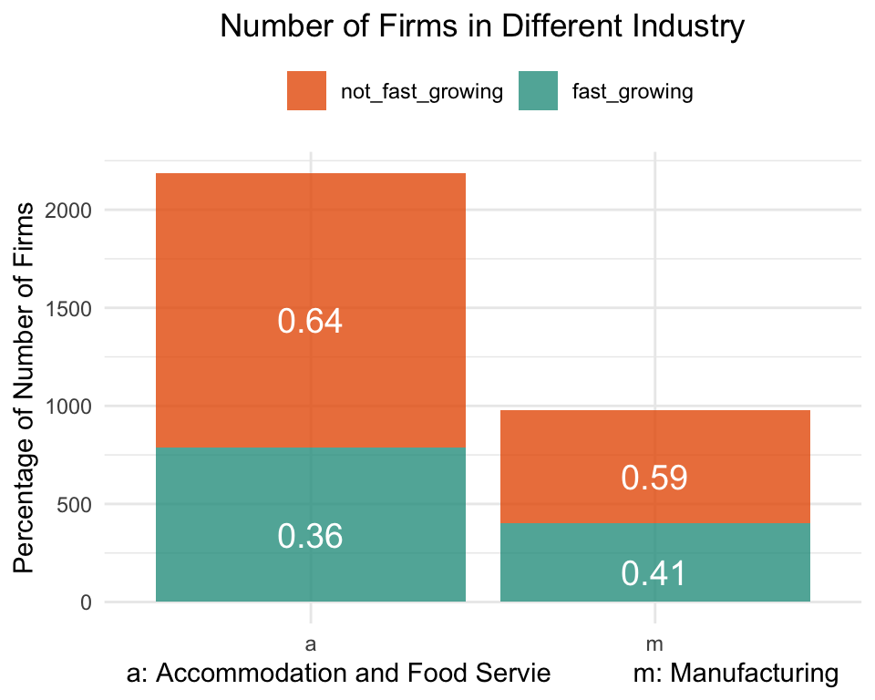

```r
# Create data set for manufacturing, accommodation and food services separately
data_m <- data_holdout %>% filter(!ind2 %in% c('55','56'))
data_a <- data_holdout %>% filter(ind2 %in% c('55','56'))

# Drop levels with zero observation for industry
data_m$ind2 <- droplevels(data_m$ind2)
data_a$ind2 <- droplevels(data_a$ind2)

data_ind <- data_holdout %>% mutate(ind= ifelse(data_holdout$ind2 %in% c('55','56'), 'a','m')) %>% group_by(ind,fast_growing_f) %>% count() %>% group_by((ind)) %>% mutate(percent= round(n/sum(n),2))

ggplot(data=data_ind, aes(x=ind, y=n, fill=fast_growing_f, label = percent))+
        geom_bar(position = position_stack(), stat = "identity", alpha=0.8)+
        geom_text(aes(label=percent), size = 5, vjust=0.9, color="white", position=position_stack(vjust=0.5)) +
        scale_fill_manual(values = c("#e85d04", "#2a9d8f"))+
        labs(y='Percentage of Number of Firms', x='a: Accommodation and Food Servie           m: Manufacturing')+
        ggtitle('Number of Firms in Different Industry')+
        theme_minimal()+
        theme(plot.title = element_text(hjust = 0.5),
              legend.position= "top",
              legend.direction = "horizontal",
              legend.title = element_blank())
```

```r
# Predict the probabilities on accommodation and food service sample
rf_predicted_probabilities_a      <- predict(best_model_with_loss, newdata = data_a, type = "prob")
data_a[,"best_model_with_loss_pred"] <- rf_predicted_probabilities_a[,"fast_growing"]

# ROC curve on accommodation and food service sample
roc_obj_a <- roc(data_a$fast_growing, data_a[, "best_model_with_loss_pred", drop=TRUE],quiet = TRUE)

# Get expected loss on accommodation and food service sample
a_treshold <- coords(roc_obj_a, x = best_model_optimal_treshold, input= "threshold",
                           ret="all", transpose = FALSE)

# Calculate the expected loss on accommodation and food service sample
expected_loss_a <- (a_treshold$fp*FP + a_treshold$fn*FN)/length(data_a$fast_growing)
#expected_loss_a #0.5569273

# Predict the probabilities on manufacturing sample
rf_predicted_probabilities_m      <- predict(best_model_with_loss, newdata = data_m, type = "prob")
data_m[,"best_model_with_loss_pred"] <- rf_predicted_probabilities_m[,"fast_growing"]

# ROC curve on manufacturing sample
roc_obj_m <- roc(data_m$fast_growing, data_m[, "best_model_with_loss_pred", drop=TRUE],quiet = TRUE)

# Get expected loss on manufacturing sample
m_treshold <- coords(roc_obj_m, x = best_model_optimal_treshold, input= "threshold",
                           ret="all", transpose = FALSE)

# Calculate the expected loss on manufacturing sample
expected_loss_m <- (m_treshold$fp*FP + m_treshold$fn*FN)/length(data_m$fast_growing)
#expected_loss_m #0.6122449
```

Afterwards, we applied our random forest model on two industry samples, estimate the expected loss. For Accommodation and Food Service sample, we get expected loss of 0.56. For Manufacturing sample, we get expected loss of 0.61. Below we can also find the confusion matrices on each sample. For Accommodation and Food Service firms, the accuracy is 52%, and 49% for firms in Manufacturing. As we can see the random forest classification performs slightly better on firms in Accommodation and Food Service than on Manufacturing. But it is still not an ideal classification for either industry, as it is no better than random guessing.

```r
# Confusion table with optimal threshold on accommodation and food service sample
a_prediction <-
        ifelse(data_a$best_model_with_loss_pred < best_model_optimal_treshold, "not_fast_growing", "fast_growing") %>%
        factor(levels = c("not_fast_growing", "fast_growing"))
cm_object_a <- confusionMatrix(a_prediction,data_a$fast_growing_f)
cm_a <- cm_object_a$table
# in pctg
cm_a_round <- round( cm_a / sum(cm_a) * 100  )
knitr::kable(cm_a_round, caption = "Confusion matrix on Accommodation and Food Service sample (%) [rows: predicted, columns: actual]" ) %>% kable_styling( position = "center", latex_options = 'hold_position' )
```

Confusion matrix on Accommodation and Food Service sample (%) [rows: predicted, columns: actual]

|  | not_fast_growing | fast_growing |
| --- | --- | --- |
| not_fast_growing | 20 | 4 |
| fast_growing | 44 | 32 |

```r
# Confusion table with optimal threshold on manufacturing sample
m_prediction <-
        ifelse(data_m$best_model_with_loss_pred < best_model_optimal_treshold, "not_fast_growing", "fast_growing") %>%
        factor(levels = c("not_fast_growing", "fast_growing"))
cm_object_m <- confusionMatrix(m_prediction,data_m$fast_growing_f)
cm_m <- cm_object_m$table
# in pctg
cm_m_round <- round( cm_m / sum(cm_m) * 100  )
knitr::kable(cm_m_round, caption = "Confusion matrix on Manufacturing sample (%) [rows: predicted, columns: actual]" ) %>% kable_styling( position = "center", latex_options = 'hold_position' )
```

Confusion matrix on Manufacturing sample (%) [rows: predicted, columns: actual]

|  | not_fast_growing | fast_growing |
| --- | --- | --- |
| not_fast_growing | 13 | 5 |
| fast_growing | 46 | 36 |

# Further Research

We would not recommend to use this model in live data, as it is not better performing than random guessing. So to get a better performing model, we might need data about more firms, explore other feature engineering choices and ideally get more predictor variables that are potentially linked to growth. In addition, we might look into other classification model choices such as GBM. If we can get a better performing model, to evaluate external validity in terms of time, we should test the model on samples across more years. We should also be careful when we want to apply the model to for example large corporate and other countries, as the external validity might be low.